# Bloque 1: Modelos usando paquetería `H2O`

Analítica basada en árboles de clasificación y regresión

Profesora: Dra. Diana Paola Montoya Escobar diana.montoya@iteso.mx

Febrero 2023

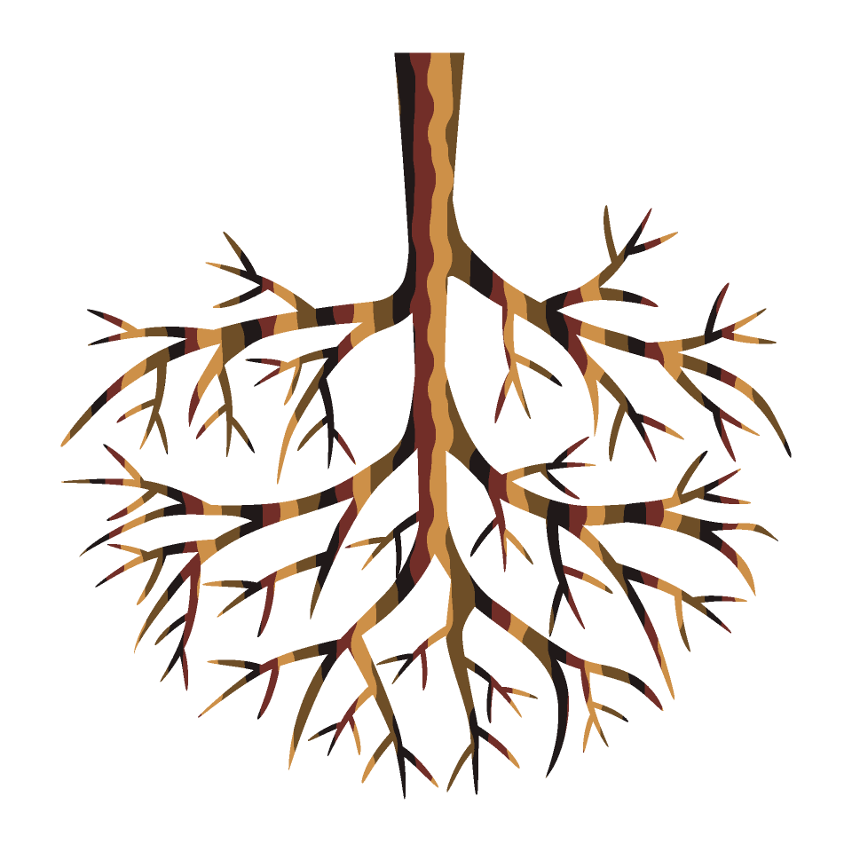

[figure not shown]

# ¿Qué es [`H20`](http://docs.h2o.ai/h2o/latest-stable/h2o-docs/index.html)?

[figure not shown]

Es un paquete creado por la compañía [H2O.ai](https://www.h2o.ai/) que busca combinar los principales algoritmos de *machine learning* y aprendizaje estadístico con el *Big Data*. Su forma de comprimir y almacenar los datos permite trabajar con millones de registros (empleando todos sus cores) o un *cluster* de muchos computadores.

Gracias a sus API, es posible acceder a todos sus funciones desde *R*, *Python* o *Scala*, así como en la interfaz web *Flow*.

# Conexión entre `H2O` Y R

Todo el manejo se hace desde R. Hay que considerar que, aunque todo se maneja desde R, los datos se encuentran en el cluster de H2O, no en memoria. Es decir, sólo cuando los datos se cargan en memoria se puede utilizar las funciones propias de R.

Las funciones `as.data.frame()` y `as.h2o()` permiten transferir datos de R al cluster de H2O y viceversa. Hay que tener cuidado cuando se transfieran datos de H2O a R, porque implica cargar en RAM todos los datos y, si son muchos, puede ocupar toda la memoria.

# Ejemplo con H2O

## Datos

Analizaremos el conjunto de datos `SaratogaHiyses`, que se encuentra en el paquete `nisaucData` (el cual usamos de ejemplo en tidymodels), el cual contiene información sobre los precio de 1,728 viviendas de Saratoga County, New York, USA en el año 2006.

```r
library(tidyverse)
data("SaratogaHouses", package = "mosaicData")
data <- SaratogaHouses
colnames(data)
```

```
 [1] "price"           "lotSize"         "age"             "landValue"       "livingArea"
 [6] "pctCollege"      "bedrooms"        "fireplaces"      "bathrooms"       "rooms"
[11] "heating"         "fuel"            "sewer"           "waterfront"      "newConstruction"
[16] "centralAir"
```

Para exportar los datos en un `.csv` lo hacemos con la siguiente función:

```r
write.csv("data","saratogaHiyses.csv")
```

## Inicialización de `H20`

Lo primero que debemos hacer es instalar el paquete `h2o` con la función en nuestra consola `install.packages("h2o")`. Para este ejemplo en `h2o`, se emplea un único computador del que se utilizan varios *cores* en paralelo.

```r
library(h2o)    # para la conexión de h2o
library(ggpubr) # paquetería que utilizaremos para visualización
```

Creamos el cluster local con todos los cores disponibles de la siguiente forma:

```r
# inicialización de h2o
h2o.init(
  ip = "localhost",
  # -1 indica que se empleen todos los cores disponibles.
  nthreads = -1,
  # Máxima memoria disponible para el cluster.
  max_mem_size = "6g"
)
```

```
H2O is not running yet, starting it now...

Note:  In case of errors look at the following log files:
    /var/folders/h0/96z_jhkn62l4b2qsgjnpd0r40000gn/T//RtmpTsEsQY/file38dd18aad8ef/h2o_paolamontoya_started_from_r.out
    /var/folders/h0/96z_jhkn62l4b2qsgjnpd0r40000gn/T//RtmpTsEsQY/file38dd78883f8f/h2o_paolamontoya_started_from_r.err
```

```
java version "1.8.0_321"
Java(TM) SE Runtime Environment (build 1.8.0_321-b07)
Java HotSpot(TM) 64-Bit Server VM (build 25.321-b07, mixed mode)
```

```
Starting H2O JVM and connecting: ..... Connection successful!

R is connected to the H2O cluster:
    H2O cluster uptime:         4 seconds 880 milliseconds
    H2O cluster timezone:       America/Mexico_City
    H2O data parsing timezone:  UTC
    H2O cluster version:        3.32.1.3
    H2O cluster version age:    1 year, 8 months and 18 days !!!
    H2O cluster name:           H2O_started_from_R_paolamontoya_vmw602
    H2O cluster total nodes:    1
    H2O cluster total memory:   5.33 GB
    H2O cluster total cores:    8
    H2O cluster allowed cores:  8
    H2O cluster healthy:        TRUE
    H2O Connection ip:          localhost
    H2O Connection port:        54321
    H2O Connection proxy:       NA
    H2O Internal Security:      FALSE
    H2O API Extensions:         Amazon S3, XGBoost, Algos, AutoML, Core V3, TargetEncoder, Core V4
    R Version:                  R version 4.0.3 (2020-10-10)
```

Se eliminan los datos del cluster por si ya había sido inicializado.

```r
h2o.removeAll()
h2o.no_progress()   # Para que no se muestre la barra de progreso.
```

## Carga de datos

La carga de datos puede hacerse directamente al cluster `H2O`, o bien cargándolos primero en memoria en la sesión de R y después transfiriéndolos. La segunda opción no es aconsejable si el volumen de datos es muy grande.

Para nuestro caso el conjunto de datos de SaratogaHouses es suficientemente pequeño y lo podemos almacenar en memoria, por tanto lo podemos llamar con la siguiente función.

```r
datos_h2o <- as.h2o(x = SaratogaHouses, destination_frame = "datos_h2o")
```

## Exploración de datos desde `h2o`

Cuando el conjunto de datos es muy grande, y no tenemos la posibilidad de utilizar las paqueterías de R para la exploración de datos, podemos hacerlo con funciones propias de `h2o`. A continuación mencionaremos algunos de los ejemplos utilizados para esta exploración:

```r
# Dimensiones del set de datos
h2o.dim(datos_h2o)
```

```
[1] 1728   16
```

```r
# Nombre de las columnas
h2o.colnames(datos_h2o)
```

```
 [1] "price"           "lotSize"         "age"             "landValue"       "livingArea"
 [6] "pctCollege"      "bedrooms"        "fireplaces"      "bathrooms"       "rooms"
[11] "heating"         "fuel"            "sewer"           "waterfront"      "newConstruction"
[16] "centralAir"
```

La función `h2o.describe()` es similar a la función `summary()`, es muy útil para obtener un análisis rápido que muestre el tipo de datos, la cantidad de valores ausentes, el valor mínimo, máximo, media, desviación típica y el número de categorías (Cardinality) de cada una de las variables. `h2o` emplea el nombre `enum` para los datos de tipo `factor` o `character`.

```r
h2o.describe(datos_h2o)
```

| Label | Type | Missing | Zeros | PosInf | NegInf | Min | Max | Mean | Sigma | Cardinality |
| --- | --- | --- | --- | --- | --- | --- | --- | --- | --- | --- |
| price | int | 0 | 0 | 0 | 0 | 5000 | 775000.0 | 2.119667e+05 | 9.844139e+04 | NA |
| lotSize | real | 0 | 2 | 0 | 0 | 0 | 12.2 | 5.002141e-01 | 6.986799e-01 | NA |
| age | int | 0 | 83 | 0 | 0 | 0 | 225.0 | 2.791609e+01 | 2.920999e+01 | NA |
| landValue | int | 0 | 0 | 0 | 0 | 200 | 412600.0 | 3.455719e+04 | 3.502117e+04 | NA |
| livingArea | int | 0 | 0 | 0 | 0 | 616 | 5228.0 | 1.754976e+03 | 6.199356e+02 | NA |
| pctCollege | int | 0 | 0 | 0 | 0 | 20 | 82.0 | 5.556771e+01 | 1.033358e+01 | NA |
| bedrooms | int | 0 | 0 | 0 | 0 | 1 | 7.0 | 3.154514e+00 | 8.173512e-01 | NA |
| fireplaces | int | 0 | 740 | 0 | 0 | 0 | 4.0 | 6.018519e-01 | 5.561022e-01 | NA |
| bathrooms | real | 0 | 1 | 0 | 0 | 0 | 4.5 | 1.900174e+00 | 6.583524e-01 | NA |
| rooms | int | 0 | 0 | 0 | 0 | 2 | 12.0 | 7.041667e+00 | 2.316453e+00 | NA |

[output cut: 6 more lines]

Para conocer el índice o nombre de las columnas que son de un determinado tipo, por ejemplo, numérico, se emplea la función `h2o.columns_by_type()`.

```r
# Índices
indices <- h2o.columns_by_type(object = datos_h2o, coltype = "numeric")
indices
```

```
 [1]  1  2  3  4  5  6  7  8  9 10
```

```r
# Nombres
h2o.colnames(x = datos_h2o)[indices]
```

```
 [1] "price"      "lotSize"    "age"        "landValue"  "livingArea" "pctCollege" "bedrooms"
 [8] "fireplaces" "bathrooms"  "rooms"
```

Con la función `h2o.cor()` se calcula la correlación entre dos o más columnas numéricas.

```r
indices <- h2o.columns_by_type(object = datos_h2o, coltype = "numeric")
h2o.cor(x = datos_h2o[, indices], y = NULL, method = "Pearson", na.rm = TRUE)
```

| price0 | lotSize0 | age0 | landValue0 | livingArea0 | pctCollege0 | bedrooms0 | fireplaces0 | bathrooms0 | rooms0 |
| --- | --- | --- | --- | --- | --- | --- | --- | --- | --- |
| 1.0000000 | 0.15833257 | -0.18879259 | 0.58126553 | 0.7123902 | 0.20011876 | 0.4003487 | 0.37678621 | 0.59724983 | 0.53117012 |
| 0.1583326 | 1.00000000 | -0.01635219 | 0.05922184 | 0.1634499 | -0.03314779 | 0.1139821 | 0.08522648 | 0.08482317 | 0.13760422 |
| -0.1887926 | -0.01635219 | 1.00000000 | -0.02181790 | -0.1742420 | -0.03778492 | 0.0271248 | -0.17202234 | -0.36189725 | -0.08226402 |
| 0.5812655 | 0.05922184 | -0.02181790 | 1.00000000 | 0.4234408 | 0.22842733 | 0.2024492 | 0.21172745 | 0.29749779 | 0.29886515 |
| 0.7123902 | 0.16344987 | -0.17424195 | 0.42344081 | 1.0000000 | 0.20998127 | 0.6561957 | 0.47378781 | 0.71856368 | 0.73366584 |
| 0.2001188 | -0.03314779 | -0.03778492 | 0.22842733 | 0.2099813 | 1.00000000 | 0.1629190 | 0.24662648 | 0.17954091 | 0.15706779 |
| 0.4003487 | 0.11398209 | 0.02712480 | 0.20244922 | 0.6561957 | 0.16291896 | 1.0000000 | 0.28447487 | 0.45803313 | 0.67186325 |
| 0.3767862 | 0.08522648 | -0.17202234 | 0.21172745 | 0.4737878 | 0.24662648 | 0.2844749 | 1.00000000 | 0.43623403 | 0.31989415 |
| 0.5972498 | 0.08482317 | -0.36189725 | 0.29749779 | 0.7185637 | 0.17954091 | 0.4580331 | 0.43623403 | 1.00000000 | 0.51758469 |
| 0.5311701 | 0.13760422 | -0.08226402 | 0.29886515 | 0.7336658 | 0.15706779 | 0.6718633 | 0.31989415 | 0.51758469 | 1.00000000 |

Para contar el número de observaciones de cada clase en una variable categórica, como es en este caso la variable `"fuel"`, se emplea la función `h2o.table()`.

```r
# Se crea una tabla con el número de observaciones de cada tipo.
tabla_muestra <- as.data.frame(h2o.table(datos_h2o$fuel))
tabla_muestra
```

| fuel | Count |
| --- | --- |
| electric | 315 |
| gas | 1197 |
| oil | 216 |

Una vez creada la tabla, se carga en el entorno de R para poder hacer la visualización.

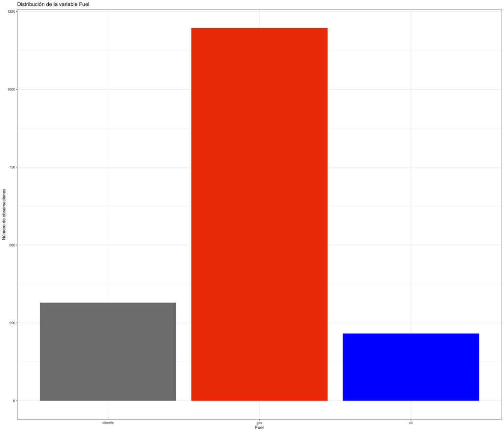

```r
ggplot(
  data = tabla_muestra,
  aes(x = fuel, y = Count, fill = fuel)) +
geom_col() +
scale_fill_manual(values = c("gray50", "orangered2","blue")) +
theme_bw() +
labs(
  x = "Fuel", y = "Número de observaciones",
  title = "Distribución de la variable Fuel") +
theme(legend.position = "none")
```

## Separación de training, validación y test

Antes de hacer la separación tengamos claro la diferencia entre estas particiones del conjunto de datos:

- **Datos de train:** la muestra de los datos utilizada para ajustar el modelo.
- **Datos de validación:** la muestra de datos que se utiliza para proporcionar una evaluación imparcial de un ajuste de modelo en el conjunto de datos de train mientras se ajustan los hiperparámetros del modelo. La evaluación se vuelve más sesgada a medida que la habilidad del conjunto de datos de validación se incorpora a la configuración del modelo.
- **Datos de test:** la muestra de datos utilizada para proporcionar una evaluación imparcial de un ajuste final del modelo en el conjunto de datos de entrenamiento.

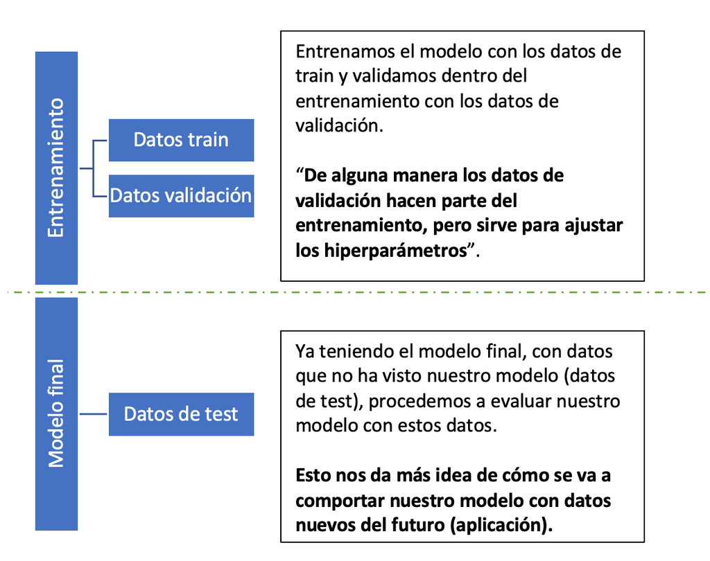

La función `h2o.splitFrame()` realiza particiones aleatorias, pero no permite hacerlas de forma estratificada, *por lo que no asegura que la distribución de clases de variable respuesta sea igual en todas particiones*. Esto puede ser problemático con datos muy desbalanceados (alguno de los grupos es muy minoritario).

Para realizar esta partición tenemos la opción de colocar los datos de training, validación y test. Como lo hicimos en el ejemplo de `tidymodels`, podemos utilizar sólo los dos primeros. Para este caso, podemos ejecutarlo de la siguiente manera:

```r
# Separación de las observaciones en conjunto de entrenamiento y test.
particiones     <- h2o.splitFrame(data = datos_h2o, ratios = c(0.8), seed = 123)
datos_train_h2o <- h2o.assign(data = particiones[[1]], key = "datos_train_H2O")
datos_test_h2o  <- h2o.assign(data = particiones[[2]], key = "datos_test_H2O")
```

En el código anterior, lo que tenemos es primero la definición de las particiones por medio de la función `h2o.splitFrame`, donde especificamos el conjunto de datos en `h2o` y la partición de los datos de training (0.8 es decir 80%), por lo tanto, el algoritmo entiende de los datos de test van a tener el 20%. Y la semilla la colocaremos con 123. Luego se especifíca cada uno de los subconjuntos y con la especificación `particiones[[1]]` estamos diciendo que este conjunto será de training. Como solo pusimos dos subconjuntos el algoritmo entenderá que el dos es de test.

En el momento en que consideremos la validación, debemos agregar en los `ratios` el porcentaje de la validación, en este caso será train (60%), validación (20%) y test (20%). En la semilla se le agrega el numeral 4 y se adiciona un nuevo subconjunto de datos, entendiendo que el 1 es train, el 2 es validación y el 3 es test.

```r
# Separación de las observaciones en conjunto de entrenamiento y test.
particiones     <- h2o.splitFrame(data = datos_h2o, ratios = c(0.6,0.2), seed = 1234)
datos_train_h2o <- h2o.assign(data = particiones[[1]], key = "datos_train_H2O")
datos_valid_h2o <- h2o.assign(data = particiones[[2]], key = "datos_valid_H2O")
datos_test_h2o  <- h2o.assign(data = particiones[[3]], key = "datos_test_H2O")
```

Podemos comparar las distribuciones de los tres subconjuntos con la función `summary`.

```r
summary(datos_train_h2o$price)
```

```
 price
 Min.   :  5000
 1st Qu.:144320
 Median :187535
 Mean   :209042
 3rd Qu.:254615
 Max.   :650000
```

```r
summary(datos_valid_h2o$price)
```

```
 price
 Min.   : 20000
 1st Qu.:144575
 Median :189875
 Mean   :217896
 3rd Qu.:258580
 Max.   :775000
```

```r
summary(datos_test_h2o$price)
```

```
 price
 Min.   : 10300
 1st Qu.:149309
 Median :190762
 Mean   :214650
 3rd Qu.:262768
 Max.   :725000
```

Podemos ver que las distribuciones son similares para los tres conjuntos de datos para este conjunto de datos.

## Procesamiento de los datos

`h2o` incorpora y automatiza muchas de las transformaciones necesarias para que los datos puedan ser ingeridos por los algoritmos de *machine learning*. Esto es distinto a la mayoría de librerías de machine learning de otros lenguajes como *Python* y *R*, donde las etapas de preprocesado suelen ser independientes del entrenamiento del modelo. En concreto, H2O automatiza las siguientes transformaciones:

### Variables categóricas en `h2o`

En el momento de ajustar un modelo (GLM, GBM, DRF, Deep Learning, K-Means, Aggregator, XGBoost), `h2o` identifica automáticamente que variables son categóricas y crea internamente las variables dummy correspondientes. Es altamente recomendable permitir que `h2o` realice este proceso en lugar de hacerlo externamente, ya que su implementación está muy optimizada. El comportamiento de la codificación de las variables categóricas puede controlarse con el argumento `categorical_encoding`, por defecto su valor es `"AUTO"`.

### Estandarización

Por defecto, `h2o` estandariza los predictores numéricos antes de ajustar los modelos para que todos tengan media cero y varianza uno. Este comportamiento se puede controlar con el argumento `standardize`. Es importante tener en cuenta que, para muchos modelos (*lasso*, *ridge*, *Deep Learning*…), es necesario realizar la estandarización de predictores.

### Eliminación de variables con varianza cero

No se deben de incluir en un modelo predictores que contengan un único valor (varianza cero), ya que no aportan información. Los algoritmos de `h2o` excluyen directamente las columnas con valor constante. Este comportamiento se puede controlar mediante el argumento `ignore_const_cols`.

### Balance de clases

Cuando hacemos problemas de clasificación, podemos tener datos desbalanceados, es decir, que el número de observaciones pertenecientes a cada grupo sea muy dispareja. Por ejemplo, tres grupos, uno de 1000, otro de 800 y otro de 200. En esos casos, el modelo puede tener dificultades para aprender a identificar las observaciones del grupo minoritario. Con el argumento `balance_classes` se puede indicar que antes de ajustar el modelo se equilibren las clases mediante undersampling u oversampling. Por defecto, este comportamiento está desactivado.

`h2o` dispone de un [listado de funciones](http://docs.h2o.ai/h2o/latest-stable/h2o-docs/data-munging.html) para manipular y transformar los datos, sin embargo, con frecuencia no son suficientes para resolver todas las necesidades de preprocesado. En estos casos es necesario recurrir a R, si el volumen de datos es limitado, o a Spark si la información no se puede cargar en memoria.

# Modelos en `h2o`

`h2o` incorpora los siguientes modelos de *machine learning*. Todos ellos están implementados de forma que puedan trabajar, en la medida de lo posible, de forma distribuida y/o en paralelo.

- Modelos supervisados

– Cox Proportional Hazards (CoxPH)

– Deep Learning (Neural Networks)

– Distributed Random Forest (DRF)

– Generalized Linear Model (GLM)

– Gradient Boosting Machine (GBM)

– Naïve Bayes Classifier

– Stacked Ensembles

– XGBoost

- Modelos no supervisados

– Aggregator

– Generalized Low Rank Models (GLRM)

– K-Means Clustering

– Isolation Forest

– Principal Component Analysis (PCA)

- Otros

– Word2vec

## Optimización de hiperparámetros

`h2o` emplea la función `h2o.grid()` para realizar la búsqueda de los mejores hiperparámetros, sus argumentos principales son: el nombre del algoritmo, los parámetros del algoritmo, una lista con los valores de los hiperparámetros que se quieren comparar, el tipo de búsqueda (“Cartesian” o “RandomDiscrete”) y, si es de tipo random, un criterio de parada. Una vez que la búsqueda ha finalizado, el objeto `grid` creado contiene todos los modelos, para acceder a ellos es necesario extraerlos.

## Comparación del ejemplo con randomForest y GBM

Ya hemos divido nuestros datos, esta vez en tres subconjuntos: train, valid, test. Si queremos ver la cabeza de los datos de train:

```r
head(datos_train_h2o)
```

|  | price | lotSize | age | landValue | livingArea | pctCollege | bedrooms | fireplaces | bathrooms | rooms | heating | fuel | sewer | waterfront | newConstruction | centralAir |
| --- | --- | --- | --- | --- | --- | --- | --- | --- | --- | --- | --- | --- | --- | --- | --- | --- |
| 1 | 181115 | 0.92 | 0 | 22300 | 1953 | 51 | 3 | 0 | 2.5 | 6 | hot water/steam | gas | septic | No | No | No |
| 2 | 86060 | 0.11 | 0 | 15000 | 840 | 51 | 2 | 0 | 1.0 | 3 | hot air | gas | public/commercial | No | Yes | Yes |
| 3 | 120000 | 0.68 | 31 | 14000 | 1152 | 22 | 4 | 1 | 1.0 | 8 | hot air | gas | septic | No | No | No |
| 4 | 153000 | 0.40 | 33 | 23300 | 2752 | 51 | 4 | 1 | 1.5 | 8 | hot water/steam | oil | septic | No | No | No |
| 5 | 170000 | 1.21 | 23 | 14600 | 1662 | 35 | 4 | 1 | 1.5 | 9 | hot air | oil | septic | No | No | No |
| 6 | 90000 | 0.83 | 36 | 22200 | 1632 | 51 | 3 | 0 | 1.5 | 8 | electric | electric | septic | No | No | No |

### Modelo con Random Forest

La función para este modelo en `h2o` es `h2o.randomForest`. Dentro de ella debemos de especificar los datos de train que convertimos dentro de `h2o` y, si así lo queremos los datos de validación. Para cuando no queremos utilizar datos de validación esta línea se omite dentro del modelo cambia la partición del conjunto de datos.

```r
random_forest_model <- h2o.randomForest(
  training_frame = datos_train_h2o, # datos de h2o para training
  validation_frame = datos_valid_h2o, # datos de h2o para validación (no es requerido)
  x = 2:16, # Las columnas predictoras, por índice
  y = 1,    # La columna que queremos predecir, variable objetivo
  model_id = "rf_covType_v1",  # nombre del modelo en h2o
  ntrees = 200, # número de árboles
  stopping_rounds = 2, # PAra cuando el promedio de dos árboles está dentro de 0.001 (predeterminado)
  score_each_iteration = T, # Predecir contra training y validación para cada árbol
  seed = 1000000  # Establecer una semilla aleatoria para que se pueda reproducir
)
```

Ahora mostremos un resumen del modelo:

```r
summary(random_forest_model)
```

```
Model Details:
==============

H2ORegressionModel: drf
Model Key:  rf_covType_v1
Model Summary:
```

|  | number_of_trees | number_of_internal_trees | model_size_in_bytes | min_depth | max_depth | mean_depth | min_leaves | max_leaves | mean_leaves |
| --- | --- | --- | --- | --- | --- | --- | --- | --- | --- |
| 1 | 11 | 11 | 88021 | 19 | 20 | 19.81818 | 615 | 651 | 632.27270 |

```
H2ORegressionMetrics: drf
** Reported on training data. **
** Metrics reported on Out-Of-Bag training samples **

MSE:  3825461093
RMSE:  61850.31
MAE:  43884.92
RMSLE:  0.3182346
Mean Residual Deviance :  3825461093


H2ORegressionMetrics: drf
** Reported on validation data. **

MSE:  4913280802
RMSE:  70094.8
MAE:  43805.3
RMSLE:  0.2829897
Mean Residual Deviance :  4913280802




Scoring History:
```

|  | timestamp | duration | number_of_trees | training_rmse | training_mae | training_deviance | validation_rmse | validation_mae | validation_deviance |
| --- | --- | --- | --- | --- | --- | --- | --- | --- | --- |
| 1 | 2023-02-07 15:20:15 | 0.191 sec | 0 | NA | NA | NA | NA | NA | NA |
| 2 | 2023-02-07 15:20:15 | 0.830 sec | 1 | 85301.62220 | 58478.62766 | 7276366750.02660 | 84622.98616 | 57981.40503 | 7161049786.27095 |
| 3 | 2023-02-07 15:20:16 | 1.013 sec | 2 | 83361.00751 | 57384.52977 | 6949057573.30376 | 80527.95507 | 53208.13547 | 6484751547.70601 |
| 4 | 2023-02-07 15:20:16 | 1.165 sec | 3 | 78618.81201 | 54093.86553 | 6180917601.59225 | 74448.66944 | 49538.80912 | 5542604381.91278 |
| 5 | 2023-02-07 15:20:16 | 1.260 sec | 4 | 74730.27315 | 51309.01093 | 5584613725.51325 | 71864.12705 | 46712.25185 | 5164452756.77738 |
| 6 | 2023-02-07 15:20:16 | 1.369 sec | 5 | 73320.23625 | 50154.87995 | 5375857043.62041 | 71041.27107 | 45969.95698 | 5046862195.31088 |
| 7 | 2023-02-07 15:20:16 | 1.504 sec | 6 | 71682.43236 | 49431.40551 | 5138371109.59075 | 69651.99691 | 44968.66853 | 4851400674.22299 |
| 8 | 2023-02-07 15:20:16 | 1.594 sec | 7 | 68142.15613 | 47608.83916 | 4643353442.28687 | 69947.74275 | 44463.48636 | 4892686715.61278 |
| 9 | 2023-02-07 15:20:16 | 1.722 sec | 8 | 67005.15349 | 47083.88397 | 4489690593.76436 | 69872.71046 | 44093.37343 | 4882195666.43412 |
| 10 | 2023-02-07 15:20:17 | 1.870 sec | 9 | 64074.71036 | 45167.90141 | 4105568508.18702 | 69421.29419 | 43634.88273 | 4819316086.71972 |

[output cut: 2 more lines]

```
Variable Importances: (Extract with `h2o.varimp`)
=================================================

Variable Importances:
```

|  | variable | relative_importance | scaled_importance | percentage |
| --- | --- | --- | --- | --- |
| 1 | livingArea | 24798541381632.000000 | 1.000000 | 0.340849 |
| 2 | landValue | 12014712782848.000000 | 0.484493 | 0.165139 |
| 3 | bathrooms | 10739994591232.000000 | 0.433090 | 0.147618 |
| 4 | bedrooms | 6595265167360.000000 | 0.265954 | 0.090650 |
| 5 | age | 3667797999616.000000 | 0.147904 | 0.050413 |
| 6 | lotSize | 3363245916160.000000 | 0.135623 | 0.046227 |
| 7 | rooms | 3035431174144.000000 | 0.122404 | 0.041721 |
| 8 | pctCollege | 2698116333568.000000 | 0.108801 | 0.037085 |
| 9 | centralAir | 1739024629760.000000 | 0.070126 | 0.023902 |
| 10 | heating | 1044798832640.000000 | 0.042131 | 0.014360 |

[output cut: 5 more lines]

Una forma más directa de acceder a las métricas de validación. Las métricas de rendimiento dependen del tipo de modelo que se está construyendo.

```r
random_forest_model@model$validation_metrics
```

```
H2ORegressionMetrics: drf
** Reported on validation data. **

MSE:  4913280802
RMSE:  70094.8
MAE:  43805.3
RMSLE:  0.2829897
Mean Residual Deviance :  4913280802
```

### Modelo con Gradient Boosting Machine (GBM)

Primero haremos todas la configuraciones predeterminadas y luego comenzaremos a hacer algunos cambios donde se describen los parámetros y los valores predeterminados.

Podemos observar una estructura muy similar a la del random forest, ahora utilizaremos la función `h2o.gbm` y lo que cambiaremos para este caso, es el `model_id`. NOTA: En la mayoría de los algoritmos el primero es para regresión y el segundo para clasificación.

```r
gbm_model <- h2o.gbm(
  training_frame = datos_train_h2o, # datos de h2o para training
  validation_frame = datos_valid_h2o, # datos de h2o para validación (no es requerido)
  x = 2:16, # Las columnas predictoras, por índice
  y = 1,    # La columna que queremos predecir, variable objetivo
  model_id = "gbm_covType1", # nombre del modelo en h2o
  seed = 2000000   # Establecer una semilla aleatoria para que se pueda reproducir
)
```

Ahora podemos hacer un resumen del modelo:

```r
summary(gbm_model)
```

```
Model Details:
==============

H2ORegressionModel: gbm
Model Key:  gbm_covType1
Model Summary:
```

|  | number_of_trees | number_of_internal_trees | model_size_in_bytes | min_depth | max_depth | mean_depth | min_leaves | max_leaves | mean_leaves |
| --- | --- | --- | --- | --- | --- | --- | --- | --- | --- |
| 1 | 50 | 50 | 15381 | 5 | 5 | 5.00000 | 8 | 30 | 19.80000 |

```
H2ORegressionMetrics: gbm
** Reported on training data. **

MSE:  1400883915
RMSE:  37428.38
MAE:  27487.22
RMSLE:  0.229347
Mean Residual Deviance :  1400883915


H2ORegressionMetrics: gbm
** Reported on validation data. **

MSE:  4145348004
RMSE:  64384.38
MAE:  41080.05
RMSLE:  0.2563413
Mean Residual Deviance :  4145348004




Scoring History:
```

|  | timestamp | duration | number_of_trees | training_rmse | training_mae | training_deviance | validation_rmse | validation_mae | validation_deviance |
| --- | --- | --- | --- | --- | --- | --- | --- | --- | --- |
| 1 | 2023-02-07 15:20:19 | 0.086 sec | 0 | 92941.84273 | 71029.63668 | 8638186129.91150 | 112390.75440 | 78158.87840 | 12631681673.83800 |
| 2 | 2023-02-07 15:20:19 | 0.247 sec | 1 | 86737.50478 | 65973.72088 | 7523394735.66015 | 106823.69353 | 73358.54615 | 11411301499.54600 |
| 3 | 2023-02-07 15:20:19 | 0.325 sec | 2 | 81377.42946 | 61591.62332 | 6622286026.16129 | 101932.29901 | 69076.09213 | 10390193580.53820 |
| 4 | 2023-02-07 15:20:19 | 0.379 sec | 3 | 76658.33761 | 57775.17265 | 5876500724.58573 | 97752.07475 | 65415.34814 | 9555468117.22153 |
| 5 | 2023-02-07 15:20:20 | 0.417 sec | 4 | 72390.65254 | 54258.54163 | 5240406575.64526 | 94020.14387 | 62214.60463 | 8839787453.77521 |

|  | timestamp | duration | number_of_trees | training_rmse | training_mae | training_deviance | validation_rmse | validation_mae | validation_deviance |
| --- | --- | --- | --- | --- | --- | --- | --- | --- | --- |
| 46 | 2023-02-07 15:20:21 | 1.831 sec | 45 | 38450.44142 | 28159.52255 | 1478436445.75129 | 65131.61595 | 41510.07945 | 4242127395.87597 |
| 47 | 2023-02-07 15:20:21 | 1.842 sec | 46 | 38303.43879 | 28047.37302 | 1467153422.84342 | 64996.35644 | 41500.92569 | 4224526350.66289 |
| 48 | 2023-02-07 15:20:21 | 1.870 sec | 47 | 38090.64400 | 27922.55200 | 1450897160.53689 | 64728.28883 | 41375.90703 | 4189751375.42827 |
| 49 | 2023-02-07 15:20:21 | 1.880 sec | 48 | 37813.61720 | 27741.43732 | 1429869645.54397 | 64494.76560 | 41197.34981 | 4159574789.30443 |
| 50 | 2023-02-07 15:20:21 | 1.893 sec | 49 | 37540.10003 | 27537.57618 | 1409259110.37842 | 64432.82582 | 41072.88446 | 4151589043.13736 |
| 51 | 2023-02-07 15:20:21 | 1.916 sec | 50 | 37428.38381 | 27487.22160 | 1400883914.71643 | 64384.37702 | 41080.04709 | 4145348004.31288 |

```
Variable Importances: (Extract with `h2o.varimp`)
=================================================

Variable Importances:
```

|  | variable | relative_importance | scaled_importance | percentage |
| --- | --- | --- | --- | --- |
| 1 | livingArea | 22376739766272.000000 | 1.000000 | 0.568137 |
| 2 | landValue | 8490311483392.000000 | 0.379426 | 0.215566 |
| 3 | bathrooms | 2031425945600.000000 | 0.090783 | 0.051577 |
| 4 | age | 1815131062272.000000 | 0.081117 | 0.046085 |
| 5 | lotSize | 1339839479808.000000 | 0.059876 | 0.034018 |
| 6 | pctCollege | 1302166896640.000000 | 0.058193 | 0.033062 |
| 7 | centralAir | 815917170688.000000 | 0.036463 | 0.020716 |
| 8 | rooms | 367628353536.000000 | 0.016429 | 0.009334 |
| 9 | fireplaces | 212277411840.000000 | 0.009487 | 0.005390 |
| 10 | heating | 176911073280.000000 | 0.007906 | 0.004492 |

[output cut: 5 more lines]

Podemos ver la evolución del modelo, para evaluar cómo aprende el modelo a medida que se añaden nuevos árboles al ensamble.

`h2o` almacena las métricas de entrenamiento y test bajo el nombre de scoring. Los valores se encuentran almacenados dentro del modelo.

```r
scoring <- as.data.frame(gbm_model@model$scoring_history)
head(scoring)
```

|  | timestamp | duration | number_of_trees | training_rmse | training_mae | training_deviance | validation_rmse | validation_mae | validation_deviance |
| --- | --- | --- | --- | --- | --- | --- | --- | --- | --- |
| 1 | 2023-02-07 15:20:19 | 0.086 sec | 0 | 92941.84 | 71029.64 | 8638186130 | 112390.75 | 78158.88 | 12631681674 |
| 2 | 2023-02-07 15:20:19 | 0.247 sec | 1 | 86737.50 | 65973.72 | 7523394736 | 106823.69 | 73358.55 | 11411301500 |
| 3 | 2023-02-07 15:20:19 | 0.325 sec | 2 | 81377.43 | 61591.62 | 6622286026 | 101932.30 | 69076.09 | 10390193581 |
| 4 | 2023-02-07 15:20:19 | 0.379 sec | 3 | 76658.34 | 57775.17 | 5876500725 | 97752.07 | 65415.35 | 9555468117 |
| 5 | 2023-02-07 15:20:20 | 0.417 sec | 4 | 72390.65 | 54258.54 | 5240406576 | 94020.14 | 62214.60 | 8839787454 |
| 6 | 2023-02-07 15:20:20 | 0.475 sec | 5 | 68726.63 | 51263.04 | 4723349965 | 90769.42 | 59465.79 | 8239087527 |

En los modelos GBM, se puede estudiar la influencia de los predictores cuantificando la reducción total de error cuadrático que ha conseguido cada predictor en el conjunto de todos los árboles que forman el modelo.

```r
importancia <- as.data.frame(gbm_model@model$variable_importances)
importancia
```

| variable | relative_importance | scaled_importance | percentage |
| --- | --- | --- | --- |
| livingArea | 2.237674e+13 | 1.000000000 | 0.568137057 |
| landValue | 8.490311e+12 | 0.379425760 | 0.215565835 |
| bathrooms | 2.031426e+12 | 0.090782928 | 0.051577145 |
| age | 1.815131e+12 | 0.081116869 | 0.046085499 |
| lotSize | 1.339839e+12 | 0.059876438 | 0.034018024 |
| pctCollege | 1.302167e+12 | 0.058192878 | 0.033061531 |
| centralAir | 8.159172e+11 | 0.036462737 | 0.020715832 |
| rooms | 3.676284e+11 | 0.016429040 | 0.009333946 |
| fireplaces | 2.122774e+11 | 0.009486521 | 0.005389644 |
| heating | 1.769111e+11 | 0.007906025 | 0.004491706 |

[output cut: 5 more lines]

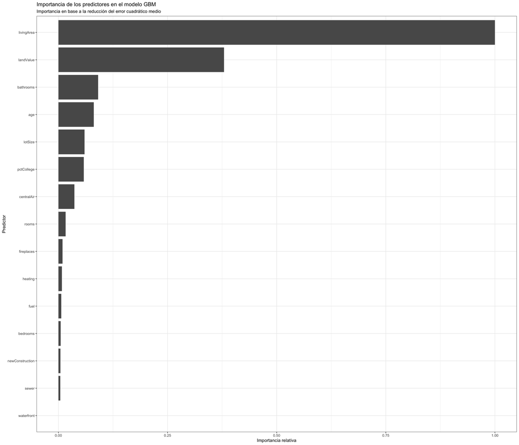

```r
ggplot(data = importancia,
       aes(x = reorder(variable, scaled_importance), y = scaled_importance)) +
  geom_col() +
  coord_flip() +
  labs(title = "Importancia de los predictores en el modelo GBM",
       subtitle = "Importancia en base a la reducción del error cuadrático medio",
       x = "Predictor",
       y = "Importancia relativa") +
  theme_bw()
```

### Modelo GBM cambiando parámetros

Ahora podemos calcular las métricas para hacer la comparación con el random forest.

```r
gbm_model@model$validation_metrics
```

```
H2ORegressionMetrics: gbm
** Reported on validation data. **

MSE:  4145348004
RMSE:  64384.38
MAE:  41080.05
RMSLE:  0.2563413
Mean Residual Deviance :  4145348004
```

En este caso, salió mejor este segundo método, pero no siempre sucede esto, especialmente cuando podemos los valores predeterminados en el modelo. Cuando esto sucede podemos ajustar nuestro modelo para mejorar el rendimiento y el tiempo de ejecución. Lo que podemos hacer es:

1. Agregar árboles, el valor predeterminado es 50.
2. Aumentar la taza de aprendizaje. Cada árbol se volverá más fuerte, por lo que el modelo lo alejará más de la media general.
3. Aumentar la profundidad. Agregar profundidad hace que cada árbol se ajuste a los datos más cercanos.

Un ejemplo cambiando estos parámetros es el siguiente:

```r
gbm_model_2 <- h2o.gbm(
  training_frame = datos_train_h2o, # datos de h2o para training
  validation_frame = datos_valid_h2o, # datos de h2o para validación (no es requerido)
  x = 2:16, # Las columnas predictoras, por índice
  y = 1,    # La columna que queremos predecir, variable objetivo
  model_id = "gbm_covType1", # nombre del modelo en h2o
  ntrees = 200,
  max_depth = 30,
  stopping_rounds = 2,
  stopping_tolerance = 1e-2,
  seed = 2000000   # Establecer una semilla aleatoria para que se pueda reproducir
)
```

Calculamos las métricas:

```r
gbm_model_2@model$validation_metrics
```

```
H2ORegressionMetrics: gbm
** Reported on validation data. **

MSE:  4522730495
RMSE:  67251.25
MAE:  41900.65
RMSLE:  0.2686802
Mean Residual Deviance :  4522730495
```

Aumentó respecto al anterior.

### Predicciones y error

Una vez hemos ajustado el modelo, se puede predecir nuevas observaciones y estimar el error de test.

```r
# Predictores para el modelo de random forest
predicciones <- h2o.predict(
  object = random_forest_model,
  newdata = datos_test_h2o
)
head(predicciones)
```

|  | predict |
| --- | --- |
| 1 | 202763.64 |
| 2 | 191090.91 |
| 3 | 127475.45 |
| 4 | 376181.18 |
| 5 | 83990.91 |
| 6 | 151938.18 |

```r
# Predictores para el modelo de GBM
predicciones_2 <- h2o.predict(
  object = gbm_model,
  newdata = datos_test_h2o
)
head(predicciones_2)
```

|  | predict |
| --- | --- |
| 1 | 191310.53 |
| 2 | 178427.40 |
| 3 | 142100.09 |
| 4 | 341921.48 |
| 5 | 83421.01 |
| 6 | 168761.14 |

Para encontrar el error (RMSE), para comparar con los modelos que hemos estudiado, podemos encontrar el valor para el modelo que hicimos para random forest.

```r
h2o.performance(model = random_forest_model, newdata = datos_test_h2o)@metrics$RMSE
```

```
[1] 56704.72
```

Y ahora bien para el modelo de GBM, el error de test será:

```r
h2o.performance(model = gbm_model, newdata = datos_test_h2o)@metrics$RMSE
```

```
[1] 55419.67
```

# Práctica No. 3

2.1 Realizar un modelo de predicción del **precio** utilizando *Random Forest* de la paquetería `tidymodels`.

2.2 Realizar un modelo de predicción del **precio** utilizando *Random Forest* de `h2o`.

2.3 Realizar un modelo de predicción del **precio** utilizando un modelo distinto de los que vimos en clase de `h2o`. [Aquí](https://rpubs.com/Joaquin_AR/406480) te dejo un link donde puedes encontrar varios modelos, pero no necesariamente te debes basar en este.

Realizar el proceso, para ambos casos, desde la partición de los datos, entrenamiento con optimización de hiperparámetros (tu decides cuál método), validación de train, modelo final y validación con datos de test.

Realizar una comparación entre modelos y definir cuál de los dos tu consideras que debería de ser el modelo para esta predicción y especificar porqué.

```r
library(tictoc)
tic()

summary(SaratogaHouses)
```

```
     price           lotSize             age           landValue        livingArea     pctCollege
 Min.   :  5000   Min.   : 0.0000   Min.   :  0.00   Min.   :   200   Min.   : 616   Min.   :20.00
 1st Qu.:145000   1st Qu.: 0.1700   1st Qu.: 13.00   1st Qu.: 15100   1st Qu.:1300   1st Qu.:52.00
 Median :189900   Median : 0.3700   Median : 19.00   Median : 25000   Median :1634   Median :57.00
 Mean   :211967   Mean   : 0.5002   Mean   : 27.92   Mean   : 34557   Mean   :1755   Mean   :55.57
 3rd Qu.:259000   3rd Qu.: 0.5400   3rd Qu.: 34.00   3rd Qu.: 40200   3rd Qu.:2138   3rd Qu.:64.00
 Max.   :775000   Max.   :12.2000   Max.   :225.00   Max.   :412600   Max.   :5228   Max.   :82.00
    bedrooms       fireplaces       bathrooms       rooms                   heating           fuel
 Min.   :1.000   Min.   :0.0000   Min.   :0.0   Min.   : 2.000   hot air        :1121   gas     :1197
 1st Qu.:3.000   1st Qu.:0.0000   1st Qu.:1.5   1st Qu.: 5.000   hot water/steam: 302   electric: 315
 Median :3.000   Median :1.0000   Median :2.0   Median : 7.000   electric       : 305   oil     : 216
 Mean   :3.155   Mean   :0.6019   Mean   :1.9   Mean   : 7.042
 3rd Qu.:4.000   3rd Qu.:1.0000   3rd Qu.:2.5   3rd Qu.: 8.250
 Max.   :7.000   Max.   :4.0000   Max.   :4.5   Max.   :12.000
               sewer      waterfront newConstruction centralAir
 septic           : 503   Yes:  15   Yes:  81        Yes: 635
 public/commercial:1213   No :1713   No :1647        No :1093
 none             :  12
```

```r
toc()
```

```
0.194 sec elapsed
```

# Referencias

- http://docs.h2o.ai/h2o-tutorials/latest-stable/index.html
- https://docs.h2o.ai/h2o/latest-stable/h2o-r/docs/reference/h2o.randomForest.html
- Joaquín Amat Rodrigo, Machine Learning con H2O y R. Abril 2020. https://rpubs.com/Joaquin_AR/406480